# Junhua Tan Final Report

Junhua Tan

06/12/2020

## Introduction

This data was uploaded on Kaggle for the purpose of training a prediction model in which predict the game outcome of a MOBA (multiplayer online battle arena) game, League of Legends (LoL), by looking at the first 10 min worth of data (data source: League of Legends Diamond Ranked Games (10 min), Version 1. Retrieved April 24, 2020 from https://www.kaggle.com/bobbyscience/league-of-legends-diamond-ranked-games-10-min). To collect this data, I will simply download from the kaggle website where the csv version of the dataset is uploaded. The data contains 1 csv file with 9879 instances of 39 attributes. Fortunately, the data has no missing values. 10% of the total data is splited as the test set for testing classification results from model building. 20% of the remaining 90% of training data is splitted for conducting an EDA previously.

## Initial Set-ups

### Load Libraries

```r
# Load packages
library(tidyverse)
library(modelr)
library(janitor)
library(skimr)
library(rsample)
library(corrplot)
library(caret)
library(glmnet)

# random forest
library(randomForest)
```

### Set Seed

```r
RNGversion("3.5")
set.seed(27182)
```

### Read processed dataset

```r
# Data is pre-splitted in data_cleaning.R
train <- read_csv(
  "data/processed/games_train.csv",
  col_types = cols(
    blue_wins = col_factor(),
    first_blood = col_factor(),
    dragons = col_factor(), # 0: None, 1: blue, -1: red
    heralds = col_factor() # 0: None, 1: blue, -1: red
  )) %>%
  clean_names()

test <- read_csv(
  "data/processed/games_test.csv",
  col_types = cols(
    blue_wins = col_factor(),
    first_blood = col_factor(),
    dragons = col_factor(), # 0: None, 1: blue, -1: red
    heralds = col_factor() # 0: None, 1: blue, -1: red
  )) %>%
  clean_names()
```

### View proportion of response variable in training data.

```r
train %>%
  skim_without_charts() # NO missing values
```

Data summary

| Name | Piped data |
| --- | --- |
| Number of rows | 7113 |
| Number of columns | 15 |
| _______________________ |  |
| Column type frequency: |  |
| factor | 4 |
| numeric | 11 |
| ________________________ |  |
| Group variables | None |

**Variable type: factor**

| skim_variable | n_missing | complete_rate | ordered | n_unique | top_counts |
| --- | --- | --- | --- | --- | --- |
| blue_wins | 0 | 1 | FALSE | 2 | 0: 3586, 1: 3527 |
| first_blood | 0 | 1 | FALSE | 2 | 1: 3612, 0: 3501 |
| dragons | 0 | 1 | FALSE | 3 | -1: 2942, 1: 2570, 0: 1601 |
| heralds | 0 | 1 | FALSE | 3 | 0: 4646, 1: 1307, -1: 1160 |

**Variable type: numeric**

| skim_variable | n_missing | complete_rate | mean | sd | p0 | p25 | p50 | p75 | p100 |
| --- | --- | --- | --- | --- | --- | --- | --- | --- | --- |
| experience | 0 | 1 | -28.52 | 1903.00 | -9333.0 | -1289.0 | -35.0 | 1210.0 | 8265.0 |
| kills | 0 | 1 | 0.09 | 4.19 | -17.0 | -3.0 | 0.0 | 3.0 | 16.0 |
| assists | 0 | 1 | 0.05 | 5.78 | -25.0 | -4.0 | 0.0 | 4.0 | 22.0 |
| towers_destroyed | 0 | 1 | 0.01 | 0.33 | -2.0 | 0.0 | 0.0 | 0.0 | 4.0 |
| wards_placed | 0 | 1 | -0.23 | 26.02 | -260.0 | -4.0 | 0.0 | 4.0 | 195.0 |
| wards_destroyed | 0 | 1 | 0.12 | 2.87 | -23.0 | -1.0 | 0.0 | 2.0 | 23.0 |
| cs_per_min | 0 | 1 | -0.07 | 3.09 | -12.0 | -2.1 | -0.1 | 2.0 | 11.5 |
| gold_per_min | 0 | 1 | 2.73 | 244.36 | -1083.0 | -156.7 | 4.2 | 161.8 | 1146.7 |
| avg_level | 0 | 1 | -0.01 | 0.47 | -2.6 | -0.4 | 0.0 | 0.2 | 2.4 |
| elite_monsters | 0 | 1 | -0.03 | 1.07 | -2.0 | -1.0 | 0.0 | 1.0 | 2.0 |
| total_jungle_minions_killed | 0 | 1 | -0.99 | 14.33 | -72.0 | -10.0 | -1.0 | 8.0 | 64.0 |

```r
# Proportions of Blue Wins (~Half)
# This is a balanced dataset.
train %>%
  count(blue_wins) %>%
  mutate(prop = n/sum(n))
```

```
## # A tibble: 2 x 3
##   blue_wins     n  prop
##   <fct>     <int> <dbl>
## 1 1          3527 0.496
## 2 0          3586 0.504
```

We have no missing values in the dataset, and the data is approximately balanced for the response variable.

### Correlation Plot

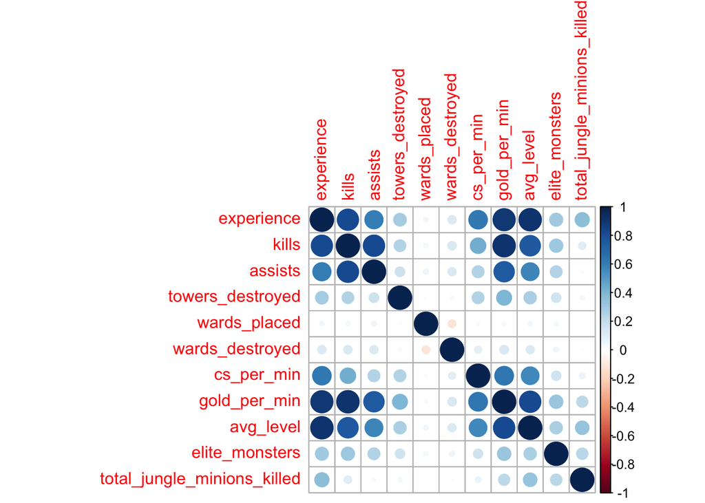

```r
train %>%
  select(-blue_wins, -first_blood, -dragons, -heralds) %>%
  cor() %>%
  corrplot()
```

However, there is high multicollinearity between variables such that most variables like `experience`, `kills`, `assists` and others are highly related.

## Best subset variable selection

```r
# 10-folds CV repeat 3 times
control <- trainControl(method='repeatedcv',
                        number=10,
                        repeats=3)
```

```r
# Helper function to calculate accuracy
calc_acc = function(actual, predicted) {
  mean(actual == predicted)
}
```

### Ridge, Lasso, and Elastic Net

```r
# Create train and test tibble
game_db <- tibble(
  train = train %>% list(),
  test = test %>% list())
```

```r
# lambda grid to search -- use for ridge&lasso classification (200 values)
lambda_grid <- 10^seq(-2, 10, length = 200)
```

#### Lasso

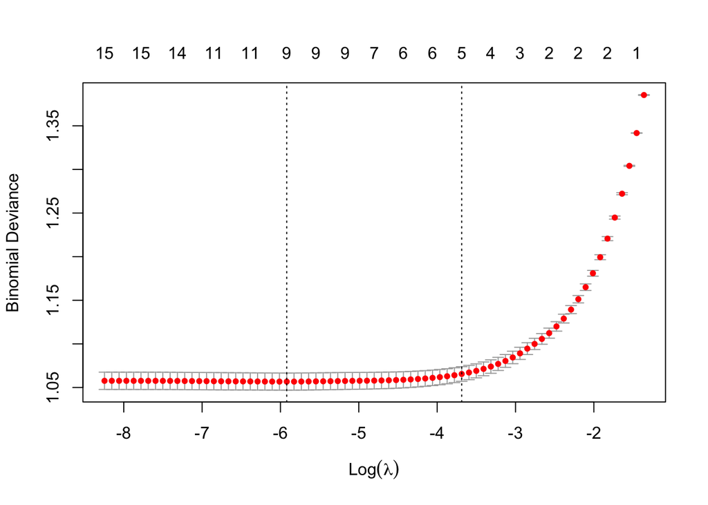

```r
# lasso: 10-fold cv
lasso_cv <- game_db %>%
  pluck("train", 1) %>%
  glmnetUtils::cv.glmnet(
    formula = blue_wins ~ . ,
    data = .,
    alpha = 1,
    nfolds = 10,
    family = "binomial"
  )

plot(lasso_cv)
```

Deviance increases as variables decreases.

```r
lasso_mod <- train(
  form = blue_wins ~ .,
  data = train,
  trControl = control,
  method = "glmnet",
  tuneGrid = expand.grid(alpha = 1, lambda = lambda_grid)
)

# Predict and test performance on test data
calc_acc(actual = test$blue_wins,
         predicted = predict(lasso_mod, newdata = test))
```

```
## [1] 0.7459514
```

```r
coef(lasso_mod$finalModel, lasso_mod$bestTune$lambda)
```

```
## 17 x 1 sparse Matrix of class "dgCMatrix"
##                                         1
## (Intercept)                  0.0619606328
## first_blood0                 .
## dragons0                     .
## dragons1                    -0.1139390116
## heralds1                     .
## heralds0                     .
## experience                  -0.0002165889
## kills                       -0.0003043757
## assists                      .
## towers_destroyed             .
## wards_placed                 .
## wards_destroyed              .
## cs_per_min                   .
## gold_per_min                -0.0033758827
## avg_level                    .
## elite_monsters              -0.0906693075
## total_jungle_minions_killed  .
```

Based on best-tuned lasso results, the variables used in training are `dragons`, `experience`, `kills`, `gold_per_min`, and `elite_monsters`.

#### Ridge

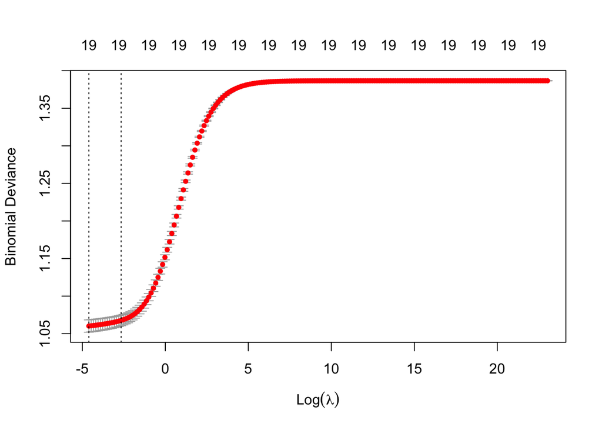

```r
# ridge regression: 10-fold cv
ridge_cv <- game_db %>%
  pluck("train", 1) %>%
  glmnetUtils::cv.glmnet(
    formula = blue_wins ~ .,
    data = .,
    alpha = 0, # for ridge regression
    nfolds = 10,
    lambda = lambda_grid,
    family = "binomial"
  )

# Check plot of cv error
plot(ridge_cv)
```

```r
ridge_mod <- train(
  form = blue_wins ~ .,
  data = train,
  trControl = control,
  method = "glmnet",
  tuneGrid = expand.grid(alpha = 0, lambda = lambda_grid)
)

# Predict and test performance on test data
calc_acc(actual = test$blue_wins,
         predicted = predict(ridge_mod, newdata = test))
```

```
## [1] 0.7419028
```

```r
coef(ridge_mod$finalModel, ridge_mod$bestTune$lambda)
```

```
## 17 x 1 sparse Matrix of class "dgCMatrix"
##                                         1
## (Intercept)                  3.995014e-02
## first_blood0                 1.155042e-01
## dragons0                    -2.519225e-02
## dragons1                    -1.515714e-01
## heralds1                    -4.372775e-02
## heralds0                    -2.283282e-02
## experience                  -9.591991e-05
## kills                       -4.050829e-02
## assists                     -2.079754e-02
## towers_destroyed            -1.078146e-01
## wards_placed                -3.090143e-04
## wards_destroyed             -6.329512e-03
## cs_per_min                  -3.283791e-02
## gold_per_min                -7.731836e-04
## avg_level                   -3.179022e-01
## elite_monsters              -8.102142e-02
## total_jungle_minions_killed -4.172927e-03
```

Based on best-tuned Ridge result, the variables that have coeffient of near +/-0.1 are `first_blood`, `dragons`, `towers_destroyed`, `avg_level`, and `elite_monsters`. Prediction using Lasso produces a slightly better accuracy of 74.5%.

## Classification Algorithm

### GLM

```r
# Using varaibles from Lasso
(glm_mod <- train(
  form = blue_wins ~ experience + kills + gold_per_min + dragons + elite_monsters,
  data = train,
  trControl = control,
  method = "glm",
  family = "binomial"
))
```

```
## Generalized Linear Model
##
## 7113 samples
##    5 predictor
##    2 classes: '1', '0'
##
## No pre-processing
## Resampling: Cross-Validated (10 fold, repeated 3 times)
## Summary of sample sizes: 6403, 6401, 6402, 6402, 6402, 6402, ...
## Resampling results:
##
##   Accuracy   Kappa
##   0.7359273  0.4718082
```

```r
# Predict and test performance on test data
calc_acc(actual = test$blue_wins,
         predicted = predict(glm_mod, newdata = test))
```

```
## [1] 0.7408907
```

```r
# Using varaibles from Ridge (coef > 0.1)
(glm_mod2 <- train(
  form = blue_wins ~ first_blood + dragons + towers_destroyed + avg_level + elite_monsters,
  data = train,
  trControl = control,
  method = "glm",
  family = "binomial"
))
```

```
## Generalized Linear Model
##
## 7113 samples
##    5 predictor
##    2 classes: '1', '0'
##
## No pre-processing
## Resampling: Cross-Validated (10 fold, repeated 3 times)
## Summary of sample sizes: 6402, 6401, 6401, 6401, 6401, 6402, ...
## Resampling results:
##
##   Accuracy   Kappa
##   0.7081839  0.4162602
```

```r
# Predict and test performance on test data
calc_acc(actual = test$blue_wins,
         predicted = predict(glm_mod2, newdata = test))
```

```
## [1] 0.7196356
```

Using linear regression with Lasso variables produced a better accuracy of 73.5% than variables from Ridge.

### KNN

```r
knn_mod = train(
  form = blue_wins ~ experience + kills + gold_per_min + dragons + elite_monsters,
  data = train,
  trControl = control,
  method = "knn",
  preProcess = c("center", "scale"),
  tuneGrid = expand.grid(k = seq(1, 101, by = 2))
)

# Predict and test performance on test data
calc_acc(actual = test$blue_wins,
         predicted = predict(knn_mod, newdata = test))
```

```
## [1] 0.7368421
```

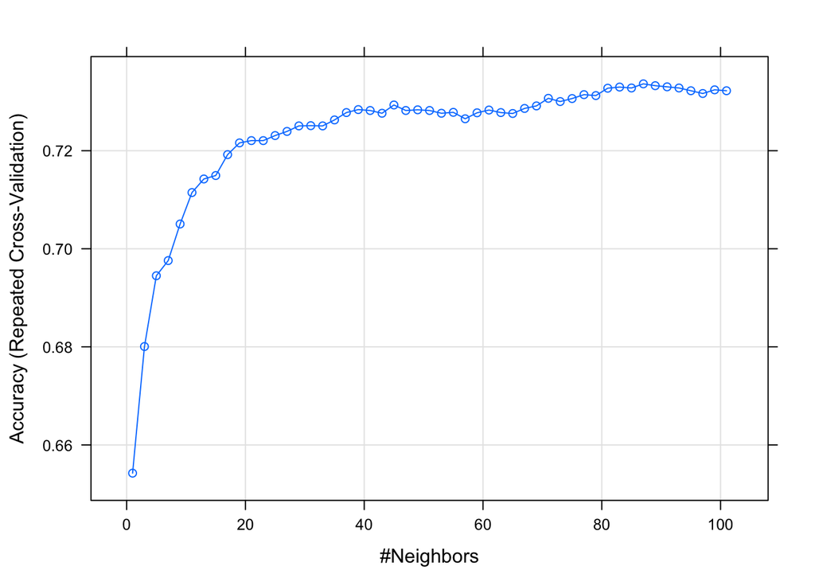

```r
plot(knn_mod)
```

```r
knn_mod$bestTune
```

```
##     k
## 44 87
```

The best-tuned k-value for KNN model is 87, and the accuracy is 73.3%.

### LDA

```r
(lda_mod = train(
  form = blue_wins ~ .,
  data = train,
  trControl = control,
  preProcess = c('scale', 'center'),
  method = "lda"
))
```

```
## Linear Discriminant Analysis
##
## 7113 samples
##   14 predictor
##    2 classes: '1', '0'
##
## Pre-processing: scaled (16), centered (16)
## Resampling: Cross-Validated (10 fold, repeated 3 times)
## Summary of sample sizes: 6403, 6401, 6401, 6403, 6401, 6401, ...
## Resampling results:
##
##   Accuracy   Kappa
##   0.7301715  0.4602945
```

```r
# Predict and test performance on test data
calc_acc(actual = test$blue_wins,
         predicted = predict(lda_mod, newdata = test))
```

```
## [1] 0.7469636
```

The predicted accuracy using LDA is highest of ~74.7%.

### Random Forest

```r
(rf_mod <- train(
  form = blue_wins ~ .,
  data = train,
  trControl = control,
  method = "rf"
))
```

```
## Random Forest
##
## 7113 samples
##   14 predictor
##    2 classes: '1', '0'
##
## No pre-processing
## Resampling: Cross-Validated (10 fold, repeated 3 times)
## Summary of sample sizes: 6402, 6402, 6401, 6401, 6401, 6401, ...
## Resampling results across tuning parameters:
##
##   mtry  Accuracy   Kappa
##    2    0.7278206  0.4555427
##    9    0.7241184  0.4481143
##   16    0.7208373  0.4415490
##
## Accuracy was used to select the optimal model using the largest value.
## The final value used for the model was mtry = 2.
```

```r
# Predict and test performance on test data
calc_acc(actual = test$blue_wins,
         predicted = predict(rf_mod, newdata = test))
```

```
## [1] 0.7287449
```

The predicted accuracy using random forest is highest of ~72.9% using mtry of 2.

## Final Result Table

```r
tibble(
  Model = c("Lasso", "Ridge", "GLM1_Lasso", "GLM2_Ridge", "KNN_87", "LDA", "Random Forest"),
  Accuracy = c(0.7459514, 0.7419028, 0.7408907, 0.7196356, 0.7368421, 0.7469636, 0.7287449)
) %>%
  arrange(desc(Accuracy))
```

```
## # A tibble: 7 x 2
##   Model         Accuracy
##   <chr>            <dbl>
## 1 LDA              0.747
## 2 Lasso            0.746
## 3 Ridge            0.742
## 4 GLM1_Lasso       0.741
## 5 KNN_87           0.737
## 6 Random Forest    0.729
## 7 GLM2_Ridge       0.720
```

Overall, the accuracies for these machine learning methods ranged between 71-74%, with LDA performs the best out of all. In the next step, I plan to work on tuning random forest and explore other possible methods such as SVM to increase the accuracy.